# 데이터 애널리틱스 중간 보고서 1조

성원호, 박유선, 허정민

2021-4-15

# 날씨에 따른 배달량의 관계 분석

## 목차

1. 주제 선정 배경
   - 1-1. 주제 선정 이유
   - 1-2. 대립 가설 설정 (유의수준: 0.05)
   - 1-3. 가설 설정의 구체화 과정
2. 데이터 수집 및 전처리
   - 2-1. 데이터 수집
   - 출처 KT 통신 Bigdata 플랫폼, 기상청
   - 2-2. 데이터 전처리
3. 데이터 분석
   - 3-1. 기술 통계
   - 날씨에 따른 배달량 분석
   - 결과 도식화
   - 3-2. 추론 통계
   - 카이스퀘어 테스트
   - T-test
   - ANOVA
4. 결론

## 1. 주제 선정 배경

### 1-1. 주제 선정 이유

> “조원들 중 한 명이 배달음식을 시켰음에도 불구하고, 눈이나 비 등 날씨가 안좋은 상황으로 인해 배달거부를 경험했다. 이러한 경험을 기반으로 기상 상황으로 인해서 다른 기상 상태에 비해 눈이나 비 등 기상상태가 좋지 않은 경우에 실질 배달량이 적은지에 대해 의문이 생겼다. 또한 배달 수요 및 공급 증가로 인해 배달 시장은 꾸준한 성장세를 보여주고 있으며 배달 데이터가 향후 시장에서 중요한 역할을 할 것이라 생각한다. 따라서 성장하는 배달 시장과 기상상황과 관련된 배달 거부 경험을 가지고, 배달량에 날씨에 밀접한 연관이 있을 것이라 생각하여 해당 주제를 선정하게 됐다.”

### 1-2. 대립 가설 설정

> “H0 : 배달량과 날씨에는 차이가 없다.”  
> “H1 : 배달량과 날씨에는 차이가 있다.”

### 1-3. 가설 설정의 구체화 과정

> 날씨에 따라 사람들의 외출 성향, 생활 패턴도 달라질 것이라 생각했기 때문에 배달 음식을 주문하는 빈도도 다를 것이라 생각했다. 때문에 기상청에서 날씨를 규정하는 기준에 따라 맑음, 더움 등의 척도를 설정하고 일일 배달량을 집계하여 분석한다면 가설에 대한 검증이 가능할 것이라 생각했다.

## 2. 데이터 수집 및 전처리

### 2-1. 데이터 수집

```r
library(dplyr)
library(tidyr)
weather_2019<- read.csv("2019년 날씨.csv", fileEncoding = "CP949", encoding = "UTF-8")
weather_2020<- read.csv("2020년 날씨.csv", fileEncoding = "CP949", encoding = "UTF-8")
delivery <- read.csv("delivery.csv", header=F, encoding = "UTF-8")
```

### 2-2. 데이터 전처리

```r
# 가독성을 위해 delivery 데이터 내의 컬럼 이름들을 변경
colnames(delivery) <- c("date","menu","province","dosi","amount")
head(delivery)
```

```
##         date   menu province              dosi amount
## 1 2019-07-18 도시락   경기도   고양시 일산동구     35
## 2 2019-07-18 도시락   경기도   고양시 일산서구     19
## 3 2019-07-18 도시락   경기도            광명시      3
## 4 2019-07-18 도시락   경기도            부천시      2
## 5 2019-07-18 도시락   경기도          의정부시     53
## 6 2019-07-18 도시락 경상남도 창원시 마산회원구     13
```

```r
# delivery 데이터에 들어 있는 지역이 광범위하므로 분석 범위를 경기도로 축소하였음.
# 이후 select 함수를 활용하여 분석에 필요한 province, menu, date 컬럼만 추출한뒤 date 기준으로 정렬
Sudo_delivery <- delivery %>%
  filter(province == "경기도" ) %>%
  select(province, menu, date) %>%
  arrange(date)

head(Sudo_delivery)
```

```
##   province        menu       date
## 1   경기도      도시락 2019-07-18
## 2   경기도      도시락 2019-07-18
## 3   경기도      도시락 2019-07-18
## 4   경기도      도시락 2019-07-18
## 5   경기도      도시락 2019-07-18
## 6   경기도 돈까스/일식 2019-07-18
```

```r
# date 컬럼은 날짜형 데이터이므로, as.Date 함수를 통해 날짜형 데이터로 변환해주어야함
Sudo_delivery$date<- as.Date(Sudo_delivery$date)

# date 컬럼을 기준으로 일일 배달량의 합계를 산출함.
Sudo_delivery_num <- Sudo_delivery %>%
  group_by(date) %>%
  summarise(
    "일일 배달량" = n()
  )


head(Sudo_delivery_num)
```

```
## # A tibble: 6 x 2
##   date       `일일 배달량`
##   <date>             <int>
## 1 2019-07-18            89
## 2 2019-07-19            94
## 3 2019-07-20            93
## 4 2019-07-21            88
## 5 2019-07-22            91
## 6 2019-07-23            91
```

```r
# 2019년과 2020년 데이터 중 분석에 사용할 컬럼만 추출
weather_2019<- weather_2019[,c(2,3,4,13,20)]
weather_2020<- weather_2020[,c(2,3,4,13,20)]

# 추출 이후 2019, 2020년도 데이터를 병합
weather<- bind_rows(weather_2019, weather_2020)

# 가독성을 높이기 위해 컬럼의 이름들을 변경하였음
colnames(weather) <- c("date","avg_temp","min_temp","precipitation", "wind_speed")

# 결측값 제거
weather[is.na(weather)]<- 0

# 평균온도와 강수량을 기준으로 수치화 된 날씨를 하나의 변수로 구체화

###--------------------------------------- 더움 -------------------------------------------------###
hot <- weather %>%
  filter(avg_temp>20, precipitation==0)
hot[,"type"] <- c("hot")
hot <- hot[,c(1,6)]
head(hot)
```

```
##         date type
## 1 2019-05-05  hot
## 2 2019-05-08  hot
## 3 2019-05-09  hot
## 4 2019-05-10  hot
## 5 2019-05-17  hot
## 6 2019-05-20  hot
```

```r
###-------------------------------------- 따뜻함 ------------------------------------------------###
warm <- weather %>%
  filter(avg_temp<=20, avg_temp>10, precipitation==0)
warm[,"type"] <- c("warm")
warm <- warm[,c(1,6)]
head(warm)
```

```
##         date type
## 1 2019-03-05 warm
## 2 2019-03-09 warm
## 3 2019-03-18 warm
## 4 2019-03-19 warm
## 5 2019-03-25 warm
## 6 2019-03-26 warm
```

```r
###--------------------------------------- 쌀쌀함 -----------------------------------------------###
cool <- weather %>%
  filter(avg_temp<=10, avg_temp>0, precipitation==0)
cool[,"type"] <- c("cool")
cool <- cool[,c(1,6)]
head(잘난척)
```

```
## Error in head(잘난척): object '잘난척' not found
```

```r
###--------------------------------------- 추움 -------------------------------------------------###
cold <- weather %>%
  filter(avg_temp<=0,precipitation==0)
cold[,"type"] <- c("cold")
cold <- cold[,c(1,6)]
head(cold)
```

```
##         date type
## 1 2019-01-01 cold
## 2 2019-01-02 cold
## 3 2019-01-03 cold
## 4 2019-01-08 cold
## 5 2019-01-09 cold
## 6 2019-01-16 cold
```

```r
###------------------------------------------비--------------------------------------------------###
rain <- weather %>%
  filter(avg_temp>=0, precipitation>0)
rain[,"type"] <- c("rain")
rain <- rain[,c(1,6)]
head(비)
```

```
## Error in head(비): object '비' not found
```

```r
###-----------------------------------------눈---------------------------------------------------###
snow <- weather %>%
  filter(min_temp<0, precipitation>0)
snow[,"type"] <- c("snow")
snow <- snow[,c(1,6)]
head(눈)
```

```
## Error in head(눈): object '눈' not found
```

```r
#각각 추출한 항목들을 정렬하여 데이터프레임화
weather_date <- bind_rows(snow, rain, warm, hot, cool, cold)
head(weather_date)
```

```
##         date type
## 1 2019-01-31 snow
## 2 2019-02-07 snow
## 3 2020-01-17 snow
## 4 2020-01-31 snow
## 5 2020-02-08 snow
## 6 2020-02-16 snow
```

```r
#731개의 데이터만 존재해야하지만, 738개의 데이터가 할당 돼있는 점을 통해 중복 데이터가 포함되어 있다는 점을 도출한 후 중복 데이터를 제거해주었음.
weather_date_2 <- weather_date[-which(duplicated(weather_date$date)),]
head(weather_date_2)
```

```
##         date type
## 1 2019-01-31 snow
## 2 2019-02-07 snow
## 3 2020-01-17 snow
## 4 2020-01-31 snow
## 5 2020-02-08 snow
## 6 2020-02-16 snow
```

```r
#weather_date_2 항목에 존재하는 date 컬럼 항목의 특성을 as.Date 함수를 사용해 날짜형 데이터로 변환
weather_date_2$date <- as.Date(weather_date_2$date)

#weather 순으로 정렬된 데이터를 날짜 순서로 정렬 (2019-07-18~2020.08.31)
weather_date_3 <- weather_date_2[order(weather_date_2$date, weather_date_2$type),]
head(weather_date_3)
```

```
##           date type
## 707 2019-01-01 cold
## 708 2019-01-02 cold
## 709 2019-01-03 cold
## 512 2019-01-04 cool
## 513 2019-01-05 cool
## 514 2019-01-06 cool
```

```r
#delivery에 존재하는 데이터는 2019년 7월 18일부터 2020년 8월 31일까지의 데이터만 존재하므로 특정 기간에 할당되는 데이터만 추출함.
weather_date_4 <- weather_date_3["2019-07-18"<= weather_date_3$date & weather_date_3$date <= "2020-08-31",]
head(weather_date_4)
```

```
##           date type
## 408 2019-07-18  hot
## 409 2019-07-19  hot
## 51  2019-07-20 rain
## 52  2019-07-21 rain
## 410 2019-07-22  hot
## 411 2019-07-23  hot
```

```r
#full_join(합집합) 함수를 통해 배달량과 정제한 날씨 데이터를 병합
delivery_weather <- full_join(Sudo_delivery_num, weather_date_4)
#결측값 제거
delivery_weather <- na.omit(delivery_weather)
head(delivery_weather)
```

```
## # A tibble: 6 x 3
##   date       `일일 배달량` type
##   <date>             <int> <chr>
## 1 2019-07-18            89 hot
## 2 2019-07-19            94 hot
## 3 2019-07-20            93 rain
## 4 2019-07-21            88 rain
## 5 2019-07-22            91 hot
## 6 2019-07-23            91 hot
```

## 3. 데이터 분석

### 3-1. 기술 통계

#### 3-1-1. 각 날씨별 빈도수, 누적 빈도, 빈도에 따른 비율, 누적 비율을 산출

- 빈도수: rain > cool > hot > warm > cold > snow  
  누적 빈도: warm > snow > rain > hot > cool > cold  
  빈도에 따른 비율: rain > cool > hot > warm > cold > snow  
  누적 비율: warm > snow > rain > hot > cool > cold

```r
#빈도수, 누적 빈도, 빈도에 따른 비율, 누적 비율을 산출
cbind(Freq=table(delivery_weather$type),
      Cumul=cumsum(table(delivery_weather$type)),
      relative=prop.table(table(delivery_weather$type)),
      Cum.prop=cumsum(prop.table(table(delivery_weather$type))))
```

```
##      Freq Cumul    relative  Cum.prop
## cold    8     8 0.019512195 0.0195122
## cool  100   108 0.243902439 0.2634146
## hot    95   203 0.231707317 0.4951220
## rain  121   324 0.295121951 0.7902439
## snow    4   328 0.009756098 0.8000000
## warm   82   410 0.200000000 1.0000000
```

##### 3-1-2. 더운 날씨에 따른 배달량

- 날씨가 더울 때의 배달량
- 최솟값: 89 1사분의수: 126.5  
  중앙값: 215  
  평균: 175.9  
  3사분위수: 224  
  최댓값: 237
- 평균: 175.9368  
  분산: 2844.081  
  표준편차: 53.32993

```r
hot_select <- subset(delivery_weather, type == "hot")
hot_summary <- summary(hot_select$`일일 배달량`)
hot_mean <- mean(hot_select$`일일 배달량`)
hot_var <- var(hot_select$`일일 배달량`)
hot_sd <- sd(hot_select$`일일 배달량`)
hot_mean <- mean(hot_select$`일일 배달량`)
head(hot_select); hot_summary; hot_mean; hot_var; hot_sd
```

```
## # A tibble: 6 x 3
##   date       `일일 배달량` type
##   <date>             <int> <chr>
## 1 2019-07-18            89 hot
## 2 2019-07-19            94 hot
## 3 2019-07-22            91 hot
## 4 2019-07-23            91 hot
## 5 2019-07-24            89 hot
## 6 2019-07-27            98 hot
```

```
##    Min. 1st Qu.  Median    Mean 3rd Qu.    Max.
##    89.0   126.5   215.0   175.9   224.0   237.0
```

```
## [1] 175.9368
```

```
## [1] 2844.081
```

```
## [1] 53.32993
```

##### 3-1-3. 따뜻한 날씨에 따른 배달량

- 날씨가 따뜻할 때의 배달량
- 최솟값: 84  
  1사분의수: 150  
  중앙값: 168.5  
  평균: 180.3  
  3사분위수: 217.5  
  최댓값: 230
- 평균: 180.2927  
  분산: 1377.543  
  표준편차: 37.11527

```r
warm_select <- subset(delivery_weather, type == "warm")
warm_summary <- summary(warm_select$`일일 배달량`)
warm_mean <- mean(warm_select$`일일 배달량`)
warm_var <- var(warm_select$`일일 배달량`)
warm_sd <- sd(warm_select$`일일 배달량`)
head(warm_select); warm_summary; warm_mean; warm_var; warm_sd
```

```
## # A tibble: 6 x 3
##   date       `일일 배달량` type
##   <date>             <int> <chr>
## 1 2019-09-12           111 warm
## 2 2019-09-13            84 warm
## 3 2019-09-16           130 warm
## 4 2019-09-19           130 warm
## 5 2019-09-20           135 warm
## 6 2019-09-21           130 warm
```

```
##    Min. 1st Qu.  Median    Mean 3rd Qu.    Max.
##    84.0   150.0   168.5   180.3   217.5   230.0
```

```
## [1] 180.2927
```

```
## [1] 1377.543
```

```
## [1] 37.11527
```

##### 3-1-4. 쌀쌀한 날씨에 따른 배달량

- 날씨가 쌀쌀할 때의 배달량
- 최솟값: 121  
  1사분의수: 182  
  중앙값: 189.5  
  평균: 193  
  3사분위수: 208  
  최댓값: 220
- 평균: 192.98  
  분산: 282.6057  
  표준편차: 16.81088

```r
cool_select <- subset(delivery_weather, type == "cool")
cool_summary <- summary(cool_select$`일일 배달량`)
cool_mean <- mean(cool_select$`일일 배달량`)
cool_var <- var(cool_select$`일일 배달량`)
cool_sd <- sd(cool_select$`일일 배달량`)
head(cool_select); cool_summary; cool_mean; cool_var; cool_sd
```

```
## # A tibble: 6 x 3
##   date       `일일 배달량` type
##   <date>             <int> <chr>
## 1 2019-11-14           169 cool
## 2 2019-11-15           173 cool
## 3 2019-11-16           169 cool
## 4 2019-11-19           167 cool
## 5 2019-11-20           171 cool
## 6 2019-11-21           173 cool
```

```
##    Min. 1st Qu.  Median    Mean 3rd Qu.    Max.
##   121.0   182.0   189.5   193.0   208.0   220.0
```

```
## [1] 192.98
```

```
## [1] 282.6057
```

```
## [1] 16.81088
```

##### 3-1-5. 추운 날씨에 따른 배달량

- 날씨가 추울 때의 배달량
- 최솟값: 182  
  1사분의수: 183  
  중앙값: 192.5  
  평균: 198  
  3사분위수: 208.2  
  최댓값: 224
- 평균: 198  
  분산: 308  
  표준편차: 17.54993

```r
cold_select <- subset(delivery_weather, type == "cold")
cold_summary <- summary(cold_select$`일일 배달량`)
cold_mean <- mean(cold_select$`일일 배달량`)
cold_var <- var(cold_select$`일일 배달량`)
cold_sd <- sd(cold_select$`일일 배달량`)
head(cold_select); cold_summary; cold_mean; cold_var; cold_sd
```

```
## # A tibble: 6 x 3
##   date       `일일 배달량` type
##   <date>             <int> <chr>
## 1 2019-12-05           183 cold
## 2 2019-12-06           182 cold
## 3 2019-12-31           195 cold
## 4 2020-01-14           183 cold
## 5 2020-02-05           224 cold
## 6 2020-02-06           224 cold
```

```
##    Min. 1st Qu.  Median    Mean 3rd Qu.    Max.
##   182.0   183.0   192.5   198.0   208.2   224.0
```

```
## [1] 198
```

```
## [1] 308
```

```
## [1] 17.54993
```

##### 3-1-6. 비오는 날씨에 따른 배달량

- 날씨가 비 올 때의 배달량
- 최솟값: 88  
  1사분의수: 152  
  중앙값: 211  
  평균: 188.9  
  3사분위수: 222  
  최댓값: 237
- 평균: 188.8595  
  분산: 1763.455  
  표준편차: 41.99351

```r
rain_select <- subset(delivery_weather, type == "rain")
rain_summary <- summary(rain_select$`일일 배달량`)
rain_mean <- mean(rain_select$`일일 배달량`)
rain_var <- var(rain_select$`일일 배달량`)
rain_sd <- sd(rain_select$`일일 배달량`)
head(rain_select); rain_summary; rain_mean; rain_var; rain_sd
```

```
## # A tibble: 6 x 3
##   date       `일일 배달량` type
##   <date>             <int> <chr>
## 1 2019-07-20            93 rain
## 2 2019-07-21            88 rain
## 3 2019-07-25            90 rain
## 4 2019-07-26            95 rain
## 5 2019-07-28            88 rain
## 6 2019-07-30            93 rain
```

```
##    Min. 1st Qu.  Median    Mean 3rd Qu.    Max.
##    88.0   152.0   211.0   188.9   222.0   237.0
```

```
## [1] 188.8595
```

```
## [1] 1763.455
```

```
## [1] 41.99351
```

##### 3-1-7. 눈오는 날씨에 따른 배달량

- 날씨가 눈 올 때의 배달량
- 최솟값: 189  
  1사분의수: 195.8  
  중앙값: 198.5  
  평균: 196.8  
  3사분위수: 199.5  
  최댓값: 201
- 평균: 196.75  
  분산: 28.25  
  표준편차: 5.315073

```r
snow_select <- subset(delivery_weather, type == "snow")
snow_summary <- summary(snow_select$`일일 배달량`)
snow_mean <- mean(snow_select$`일일 배달량`)
snow_var <- var(snow_select$`일일 배달량`)
snow_sd <- sd(snow_select$`일일 배달량`)
head(snow_select); snow_summary; snow_mean; snow_var; snow_sd
```

```
## # A tibble: 4 x 3
##   date       `일일 배달량` type
##   <date>             <int> <chr>
## 1 2020-01-17           189 snow
## 2 2020-01-31           199 snow
## 3 2020-02-08           198 snow
## 4 2020-02-16           201 snow
```

```
##    Min. 1st Qu.  Median    Mean 3rd Qu.    Max.
##   189.0   195.8   198.5   196.8   199.5   201.0
```

```
## [1] 196.75
```

```
## [1] 28.25
```

```
## [1] 5.315073
```

##### 3-1-8. psych패키지를 이용한 기술통계량

```r
#install.packages("psych")
library(psych)
#psych 패키지는 기술통계량을 출력해주는 유용한 함수들의 집합
#describe는 기술 통계 중에서도 양적자료를 출력해주는 함수
hot_des <- describe(hot_select$`일일 배달량`)
warm_des <- describe(warm_select$`일일 배달량`)
cool_des <- describe(cool_select$`일일 배달량`)
cold_des <- describe(cold_select$`일일 배달량`)
rain_des <- describe(rain_select$`일일 배달량`)
snow_des <- describe(snow_select$`일일 배달량`)

#weather_select에 날씨별로 분석한 기술 통계들을 병합
weather_select <-  bind_rows(hot_des, warm_des, cool_des, cold_des, rain_des, snow_des)

#가독성을 위해 행 이름 변경
rownames(weather_select) <- c("hot", "warm", "cool", "cold", "rain", "snow")

head(weather_select)
```

```
##      vars   n   mean    sd median trimmed   mad min max range  skew kurtosis
## hot     1  95 175.94 53.33  215.0  179.13 23.72  89 237   148 -0.28    -1.75
## warm    1  82 180.29 37.12  168.5  181.68 56.34  84 230   146 -0.17    -1.27
## cool    1 100 192.98 16.81  189.5  193.49 20.02 121 220    99 -0.65     1.57
## cold    1   8 198.00 17.55  192.5  198.00 14.83 182 224    42  0.55    -1.57
## rain    1 121 188.86 41.99  211.0  193.92 23.72  88 237   149 -0.89    -0.55
## snow    1   4 196.75  5.32  198.5  196.75  2.22 189 201    12 -0.62    -1.76
##        se
## hot  5.47
## warm 4.10
## cool 1.68
## cold 6.20
## rain 3.82
## snow 2.66
```

##### 3-1-9. 날씨별 빈도에 따른 원형 그래프

- 날씨별 빈도: rain > cool > hot > warm > cold > snow

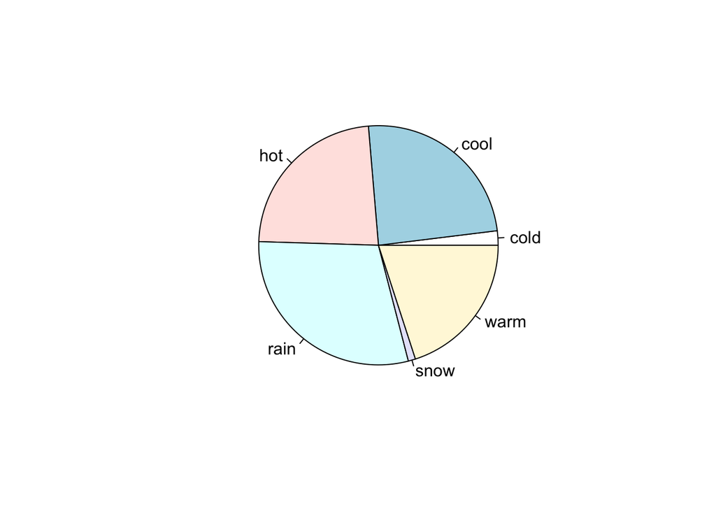

```r
#원형 그래프를 통해 날씨별 빈도를 도식화
pie(table(delivery_weather$type))
```

##### 3-1-10. 날씨별 빈도에 따른 막대 그래프

- 날씨별 빈도: rain > cool > hot > warm > cold > snow

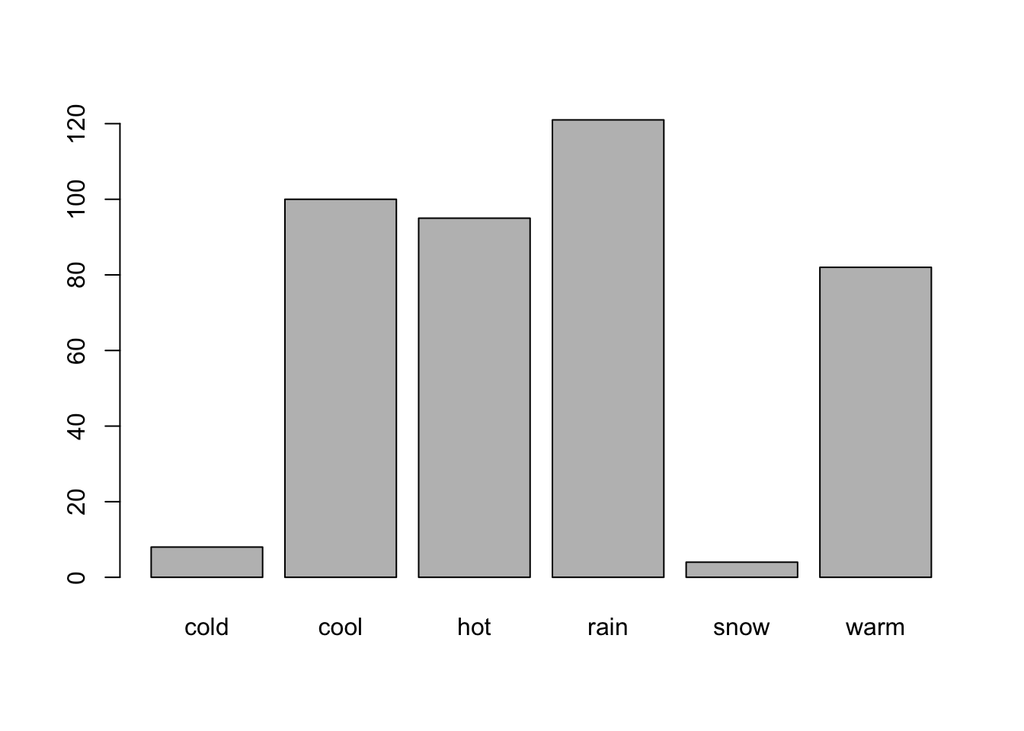

```r
#막대형 그래프를 통해 날씨별 빈도를 도식화
barplot(table(delivery_weather$type))
```

##### 3-1-11. 날씨별 일일 배달량 비율에 따른 3D 파이차트

- 날씨별 일일 배달량 비율: cold > snow > cool > rain > warm > hot  
  이 3D파이차트를 이용해서 hot, warm, cool, cold, rain, snow 이 여섯개의 날씨별로 배달량의 평균의 확률을 확인 할 수 있다.이를 통해서 크게 차이나는 경우는 없는 것을 확인 할 수 있다.

```r
#install.packages("plotrix")
library(plotrix)
#3D 파이차트를 통해 날씨별 일일 배달량 비율 도식화
weather_mean<- c(hot_mean, warm_mean, cool_mean, cold_mean, rain_mean, snow_mean)
weather_name<- c("hot", "warm", "cool", "cold", "rain", "snow")
wpt<- round(100*prop.table(weather_mean), 1)
lbl_w_wpt<- paste(weather_name, wpt)
lbl_w_wpt<- paste0(lbl_w_wpt,"%")
```

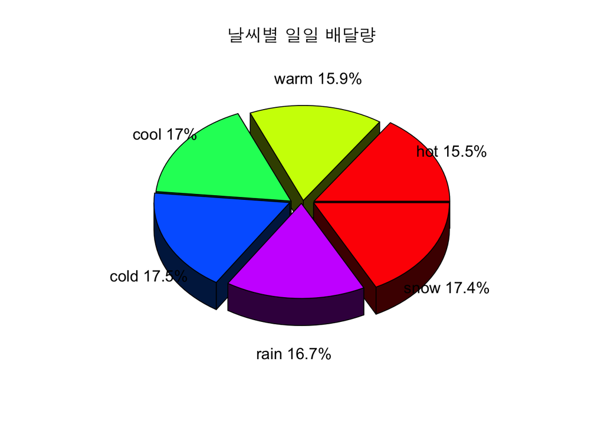

```r
pie3D(wpt, labels = lbl_w_wpt, col=rainbow(5),
      main ="날씨별 일일 배달량", family = "AppleGothic",
      labelcex=1.1, explode=0.1, theta=1.1, shade=0.3)
```

##### 3-1-12. 날씨별 일일 배달량 비율에 따른 막대그래프

- 날씨별 일일 배달량 비율: cold > snow > cool > rain > warm > hot  
  barplot을 이용해서 각 날씨별로 일일배달량 평균을 도식화하였다. 이를 통해서 크게 차이나는 경우는 없는 것을 확인 할 수 있다.

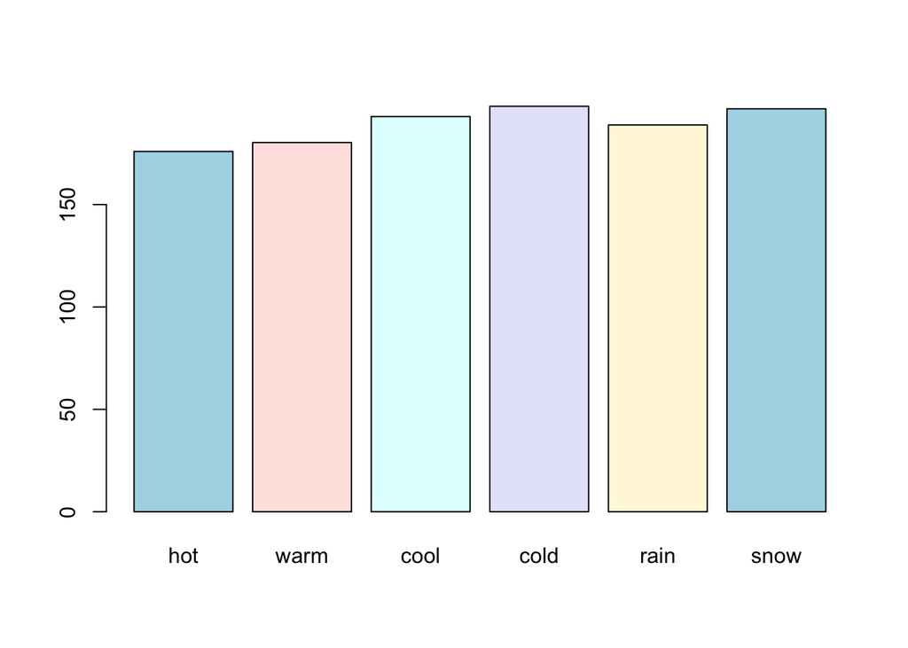

```r
#막대형 그래프 각 컬럼에 이름 추가
row.names(weather_select) <- c("hot", "warm", "cool", "cold", "rain", "snow")

#막대형 그래프를 통해 날씨별 평균 배달량을 도식화
barplot(weather_select$mean,names= c("hot", "warm", "cool", "cold", "rain", "snow"),col=c("lightblue", "mistyrose", "lightcyan", "lavender", "cornsilk"))
```

#### 3-2. 추론 통계

##### 3-2-1. 온도에 따른 추론 통계(일원분석)

###### 3-2-1-1. 추론통계를 위한 전처리

```r
#H0 : 배달량과 날씨에는 차이가 없다.
#H1 : 배달량과 날씨에는 차이가 있다.

#추론 통계를 위해 온도를 기준으로, 강수 유무를 기준으로 2개의 그룹으로 나누어줌
weather_abs <- weather[, c(1,2,4)]

#배달량 데이터와 데이터프레임의 열,행이 일치해야 하므로 통일된 날짜만 추출
weather_date_abs <- weather_abs["2019-07-18"<= weather_abs$date & weather_abs$date <= "2020-08-31",]

#배달량 데이터에 5월 18일 자료가 빠져 있으므로 날씨 데이터에서도 제거
weather_null_del <- weather_date_abs[!(weather_date_abs$date =="2020-05-18"),]

#분석에 필요하지 않은 컬럼 제거
weather_date_del <- weather_null_del[, -1]

#정제된 배달 데이터와 추론 통계용 날씨 데이터를 병합
weather_total <- cbind(delivery_weather, weather_date_del)
head(weather_total)
```

```
##           date 일일 배달량 type avg_temp precipitation
## 199 2019-07-18          89  hot     24.4           0.0
## 200 2019-07-19          94  hot     24.0           0.0
## 201 2019-07-20          93 rain     23.0          13.1
## 202 2019-07-21          88 rain     22.5           5.0
## 203 2019-07-22          91  hot     31.1           0.0
## 204 2019-07-23          91  hot     30.4           0.0
```

```r
#가독성을 위해 컬럼명을 영문으로 통일 "일일 배달량" -> "Daily delivery"
names(weather_total)[2]<- "Daily delivery"

#온도를 17도 기준으로 두개의 그룹으로 세분화
low_weather <- subset(weather_total, avg_temp < 17)
high_weather <- subset(weather_total, avg_temp >= 17)

#이후 17도 미만의 온도는 "low"로, 17도 이상의 온도는 "high"로 하여 두개의 값으로만 표현
low_weather$avg_temp<- "low"
high_weather$avg_temp <- "high"

#full_join(합집합) 함수를 통해 재결합
weather_total <- full_join(low_weather, high_weather)
head(weather_total)
```

```
##         date Daily delivery type avg_temp precipitation
## 1 2019-09-22            127 rain      low          58.8
## 2 2019-10-05            138 rain      low          46.4
## 3 2019-10-06            132 warm      low           0.0
## 4 2019-10-07            150 warm      low           0.0
## 5 2019-10-08            145 warm      low           0.0
## 6 2019-10-09            146 warm      low           0.0
```

```r
#카이스퀘어 테스트를 위해 low 데이터와 high 데이터의 합계 추출
low_sum <- sum(low_weather$`Daily delivery`)
high_sum <- sum(high_weather$`Daily delivery`)
low_high <- c(high_sum, low_sum)
#as.table 함수를 통해 table형 데이터로 변환
degree_table <- as.table(low_high)
degree_table
```

```
##     A     B
## 34475 41544
```

###### 3-2-1-2. 온도에 따른 카이스퀘어 테스트

```r
chisq.test(degree_table)
```

```
##
##  Chi-squared test for given probabilities
##
## data:  degree_table
## X-squared = 657.35, df = 1, p-value < 2.2e-16
```

- 온도를 기준으로 분석한 카이스퀘어 테스트를 해보면 카이스퀘어 자승값이 657.35이고 p-value값이 2.2e-16보다 작다는 결과를 얻을 수 있다. 이는 온도와 배달량 사이의 관계는 서로 관련이 있는 것을 확인할 수 있다. 그렇기에 온도에 따라 배달량 빈도와 차이가 있다고 볼 수 있다.

###### 3-2-1-3. 온도를 기준으로 한 정규성 분포 검정

```r
output_temp <- lm(weather_total$`Daily delivery`~weather_total$avg_temp)
shapiro.test(resid(output_temp))
```

```
##
##  Shapiro-Wilk normality test
##
## data:  resid(output_temp)
## W = 0.93367, p-value = 1.557e-12
```

###### 3-2-1-4. 온도에 따른 분산 동질성 검증

```r
var.test(weather_total$`Daily delivery` ~ weather_total$avg_temp)
```

```
##
##  F test to compare two variances
##
## data:  weather_total$`Daily delivery` by weather_total$avg_temp
## F = 4.7398, num df = 191, denom df = 217, p-value < 2.2e-16
## alternative hypothesis: true ratio of variances is not equal to 1
## 95 percent confidence interval:
##  3.601849 6.252716
## sample estimates:
## ratio of variances
##           4.739844
```

- 온도를 기준으로 분산 동질성 검증을 한 결과 F 값은 4.7398이고, 온도별 자유도는 각각 191, 217 유의도는 2.2e-16으로 0.05보다 낮으므로 분산이 같지 않다. 따라서 Welch’s test를 사용해야 한다.

###### 3-2-1-5. 온도에 따른 t-test

```r
#t-test
t.test(weather_total$`Daily delivery` ~ weather_total$avg_temp, var.equal = F)
```

```
##
##  Welch Two Sample t-test
##
## data:  weather_total$`Daily delivery` by weather_total$avg_temp
## t = -2.7207, df = 260.65, p-value = 0.006953
## alternative hypothesis: true difference in means is not equal to 0
## 95 percent confidence interval:
##  -18.981073  -3.041958
## sample estimates:
## mean in group high  mean in group low
##           179.5573           190.5688
```

- 평균온도를 독립변수로 두고 일일배달량을 종속변수로 두어서 온도를 기준으로 분석한 t-test의 결과를 보면 t값은 -2.7202이고 자유도는 260.65이며 유의도가 0.0069533이다. 그렇기에 유의도가 유의수준보다 낮기에 온도에 따라 배달량의 차이가 있다가 볼 수 있다.

###### 3-2-1-6. 온도에 따른 ANOVA(분산분석)

```r
#온도에 따른 ANOVA(분산분석)
head(weather_total)
```

```
##         date Daily delivery type avg_temp precipitation
## 1 2019-09-22            127 rain      low          58.8
## 2 2019-10-05            138 rain      low          46.4
## 3 2019-10-06            132 warm      low           0.0
## 4 2019-10-07            150 warm      low           0.0
## 5 2019-10-08            145 warm      low           0.0
## 6 2019-10-09            146 warm      low           0.0
```

```r
anova_temp <- aov(weather_total$`Daily delivery` ~ weather_total$avg_temp)
summary(anova_temp)
```

```
##                         Df Sum Sq Mean Sq F value Pr(>F)
## weather_total$avg_temp   1  12379   12379   8.042 0.0048 **
## Residuals              408 628005    1539
## ---
## Signif. codes:  0 '***' 0.001 '**' 0.01 '*' 0.05 '.' 0.1 ' ' 1
```

```r
anova_temp
```

```
## Call:
##    aov(formula = weather_total$`Daily delivery` ~ weather_total$avg_temp)
##
## Terms:
##                 weather_total$avg_temp Residuals
## Sum of Squares                 12378.5  628004.8
## Deg. of Freedom                      1       408
##
## Residual standard error: 39.23299
## Estimated effects may be unbalanced
```

###### 3-2-1.7. 온도를 기준으로 한 등분산성 검정

```r
library(car)
leveneTest(weather_total$`Daily delivery`~weather_total$avg_temp)
```

```
## Levene's Test for Homogeneity of Variance (center = median)
##        Df F value    Pr(>F)
## group   1  63.227 1.827e-14 ***
##       408
## ---
## Signif. codes:  0 '***' 0.001 '**' 0.01 '*' 0.05 '.' 0.1 ' ' 1
```

- 분석결과 p-value는 1.827e-14로 유의수준 0.05에서 귀무가설을 기각하게 되므로 등분산을 만족하지 않는다.

###### 3-2-1-8. 온도에 따른 일일 배달량 정도 그래프

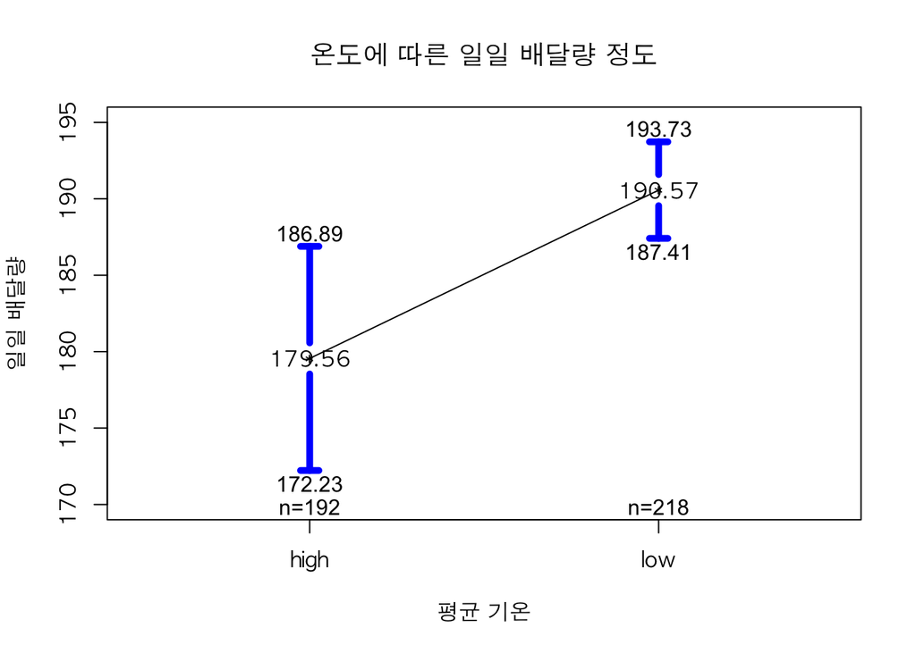

```r
#install.packages("gplots")
library(gplots)
#gplot 패키지 중 plotmeans 함수를 통해 도식화
#x축은 평균기온, y축은 일일 배달량으로 설정하고, 최소값은 170, 최대값은 195로 설정 후 main 값에 제목을 할당해줌
plotmeans(weather_total$`Daily delivery`~ weather_total$avg_temp, family = "AppleGothic", xlab="평균 기온", ylab= "일일 배달량", ci.label = TRUE, mean.label = TRUE, ylim=c(170,195), barwidth=5, main="온도에 따른 일일 배달량 정도", digits=2, pch="*")
```

- 이 plotmean을 이용해서 온도의 높고 낮음 따른 일일 배달량 정도를 확인 할 수 있다. 이는 온도가 높은 경우 배달량의 평균과 최솟값, 최댓값 그리고 온도가 낮은 경우에 배달량의 평균과 최솟값, 최댓값을 보여준다. 이 그래프를 통해서 온도가 높은 경우보다 낮은 경우에 배달량이 더 높은 것을 확인할 수 있다.

##### 3-2-2. 강수 유무에 따른 추론 통계(일원분석)

###### 3-2-2-1. 추론통계를 위한 전처리

```r
#강수량 0, 강수량 0 초과를 기준으로 두개의 그룹으로 세분화
wet_weather <- subset(weather_total, precipitation > 0)
dry_weather <- subset(weather_total, precipitation = 0)

#강수량 0 초과는 "wet", 0은 "dry"로 하여 두개의 값으로만 표현
wet_weather$precipitation<- "wet"
dry_weather$precipitation <- "dry"

#full_join(합집합) 함수를 통해 재결합
weather_total_wd <- full_join(wet_weather, dry_weather)
head(weather_total_wd)
```

```
##         date Daily delivery type avg_temp precipitation
## 1 2019-09-22            127 rain      low           wet
## 2 2019-10-05            138 rain      low           wet
## 3 2019-10-14            148 rain      low           wet
## 4 2019-10-15            146 rain      low           wet
## 5 2019-10-18            152 rain      low           wet
## 6 2019-11-03            161 rain      low           wet
```

```r
#카이스퀘어 테스트를 위해 wet과 dry의 합계 추출
wet_sum<- sum(wet_weather$`Daily delivery`)
dry_sum <- sum(dry_weather$`Daily delivery`)
wet_dry <- c(wet_sum, dry_sum)
#as.table 함수를 통해 table형 함수로 변환
pre_table <- as.table(wet_dry)
pre_table
```

```
##     A     B
## 23639 76019
```

###### 3-2-2-2. 강수 유무에 따른 카이스퀘어 테스트

```r
#카이스퀘어 테스트
chisq.test(pre_table)
```

```
##
##  Chi-squared test for given probabilities
##
## data:  pre_table
## X-squared = 27531, df = 1, p-value < 2.2e-16
```

- 강수 유무를 기준으로 분석한 카이스퀘어 테스트를 해보면 카이스퀘어 자승값이 27531이고 p-value값이 2.2e-16보다 작다는 결과를 얻을 수 있다. 이는 유의확률이 거의 0에 가까운 값이라는 의미로 확인할 수 있다. 그렇기에 이는 강수량과 배달량 사이의 관계는 서로 관련이 있는 것을 확인할 수 있다. 그렇기에 강수 유무에 따라 배달량의 빈도에 차이가 있다고 볼 수 있다.

###### 3-2.2.3. 강수 유무를 기준으로 한 정규성 검정 분포

```r
output_prec <- lm(weather_total_wd$`Daily delivery`~weather_total_wd$precipitation)
shapiro.test(resid(output_prec))
```

```
##
##  Shapiro-Wilk normality test
##
## data:  resid(output_prec)
## W = 0.88414, p-value < 2.2e-16
```

- p-value가 2.2e-16으로 0.05보다 작으므로 정규분포를 따르지 않는다.

###### 3-2-2-4. 강수 유무에 따른 분산 동질성 검증

```r
var.test(weather_total_wd$`Daily delivery` ~ weather_total_wd$precipitation)
```

```
##
##  F test to compare two variances
##
## data:  weather_total_wd$`Daily delivery` by weather_total_wd$precipitation
## F = 0.91606, num df = 409, denom df = 124, p-value = 0.5257
## alternative hypothesis: true ratio of variances is not equal to 1
## 95 percent confidence interval:
##  0.6812307 1.2050421
## sample estimates:
## ratio of variances
##          0.9160614
```

- 강수 유무를 기준으로 분산 동질성 검증을 한 결과 F 값은 0.91606이고, 강수유무 자유도는 각각 409, 124 유의도는 0.5257으로 0.05보다 크다. 따라서 두 집단의 분산이 같다는 가정으로 T검증을 수행할 수 있다.

###### 3-2-2-5. 강수 유무에 따른 t-test

```r
#t-test
t.test(weather_total_wd$`Daily delivery` ~ factor(weather_total_wd$precipitation))
```

```
##
##  Welch Two Sample t-test
##
## data:  weather_total_wd$`Daily delivery` by factor(weather_total_wd$precipitation)
## t = -0.88461, df = 198.25, p-value = 0.3774
## alternative hypothesis: true difference in means is not equal to 0
## 95 percent confidence interval:
##  -11.947498   4.547888
## sample estimates:
## mean in group dry mean in group wet
##          185.4122          189.1120
```

- 강수량을 독립변수로 두고 일일배달량을 종속변수로 두어서 강수량을 기준으로 분석한 t-test의 결과를 보면 t값은 -0.88461이고 자유도는 198.25이며 유의도가 0.3774이다. 그렇기에 유의도가 유의수준보다 높기 때문에 강수 유무에 따른 배달량에 차이가 없다고 볼 수 있다.

###### 3-2-2-6. 강수 유무에 따른 ANOVA(분산분석)

```r
#강수 유무에 따른 분산분석
anova_pre <- aov(weather_total_wd$`Daily delivery` ~ factor(weather_total_wd$precipitation))
summary(anova_pre)
```

```
##                                         Df Sum Sq Mean Sq F value Pr(>F)
## factor(weather_total_wd$precipitation)   1   1311    1311    0.82  0.366
## Residuals                              533 852324    1599
```

- 집단 간 제곱값은 1311이고, 자유도는 1이므로 집단 간 평균 제곱합은 1311이다. 집단 내 제곱합은 852324이고, 자유도는 533이므로 집단내 평균 제곱합은 1599이다. F값은 집단 간 평균 제곱합을 집단 내 평균 제곱합으로 나눈 0.82가 되어 집단 간 제곱합의 자유도와 집단 내 제곱합의 자유도를 감안한 유의도는 0.366으로 기각을 판단할 수 있는 기준인 0.05보다 높게 나타나므로 강수 유무에 따른 배달량에 영향이 없다는 가설을 채택하게 된다 .

###### 3-2-2.7. 강수 유무를 기준으로 한 등분산성 검정

```r
leveneTest(weather_total_wd$`Daily delivery`~weather_total_wd$precipitation)
```

```
## Levene's Test for Homogeneity of Variance (center = median)
##        Df F value Pr(>F)
## group   1  0.0274 0.8686
##       533
```

- 분석결과 P-value는 0.8686으로 유의 수준 0.05에서 귀무가설을 기각하지 못하므로 등분산을 만족한다.

###### 3-2-2-8. 강수 유무에 따른 일일 배달량 정도 그래프

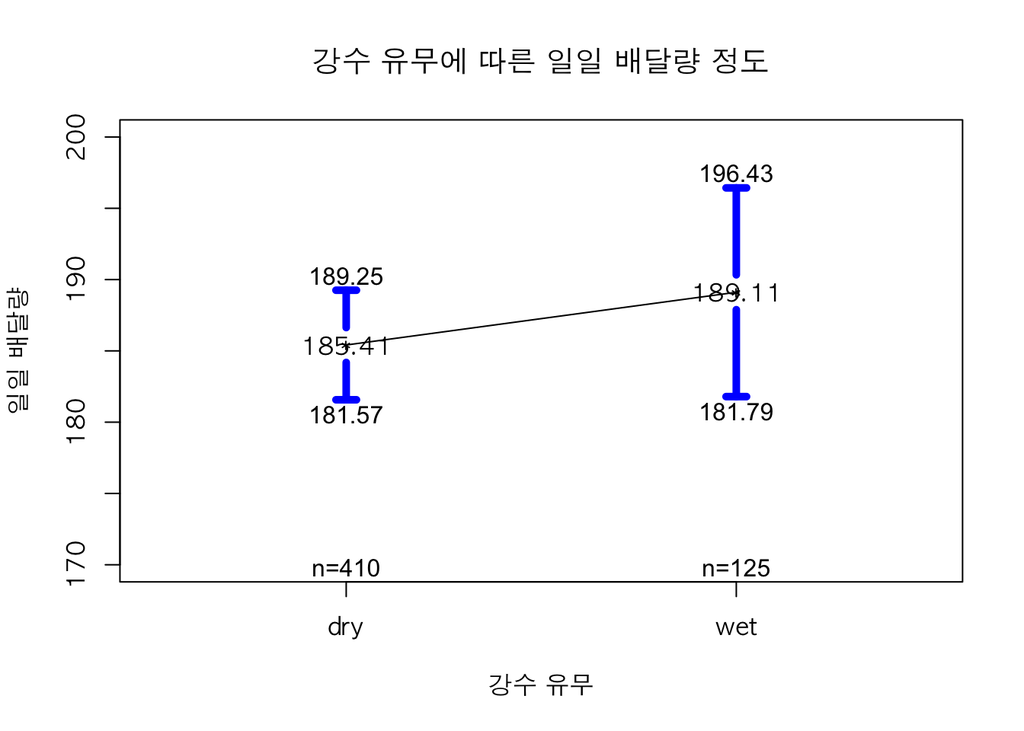

```r
plotmeans(weather_total_wd$`Daily delivery` ~ weather_total_wd$precipitation, family = "AppleGothic", xlab="강수 유무", ylab = "일일 배달량", ci.label = TRUE, mean.label = TRUE, ylim=c(170, 200), barwidth=5, main="강수 유무에 따른 일일 배달량 정도", digits = 2, pch="*")
```

- 이 plotmean을 이용해서 강수 유무에 따른 일일 배달량 정도를 확인 할 수 있다. 이는 강수량이 0보다 큰 값들의 배달량의 평균과 최솟값, 최댓값, 그리고 강수량이 0인 경우에 배달량의 평균과 최솟값, 최댓값을 보여준다. 이 그래프를 통해서 강수량이 있을 때와 강수량이 없을 때에 배달량의 정도가 큰 차이는 없다는 것을 볼 수 있다. 하지만 강수량이 있을 때 최댓값이 높은 것을 보면 배달을 더 많이 시키는 경향을 확인 할 수 있다.

##### 3-2-3. 사후검정

###### 3-2-3-1. 온도 변수에 대한 사후검정

```r
TukeyHSD(anova_temp)
```

```
##   Tukey multiple comparisons of means
##     95% family-wise confidence level
##
## Fit: aov(formula = weather_total$`Daily delivery` ~ weather_total$avg_temp)
##
## $`weather_total$avg_temp`
##              diff      lwr      upr    p adj
## low-high 11.01152 3.378383 18.64465 0.004798
```

###### 3-2-3-2. 강수 유무 변수에 대한 사후검정

```r
TukeyHSD(anova_pre)
```

```
##   Tukey multiple comparisons of means
##     95% family-wise confidence level
##
## Fit: aov(formula = weather_total_wd$`Daily delivery` ~ factor(weather_total_wd$precipitation))
##
## $`factor(weather_total_wd$precipitation)`
##             diff       lwr     upr     p adj
## wet-dry 3.699805 -4.326285 11.7259 0.3655857
```

##### 3-2-4. 온도와 강수 유무를 기준으로 한 추론 통계(이원분석)

###### 3-2-4-1. 배달량의 주효과와 상호작용 효과

```r
#독립변수의 주효과와 상호작용 효과 둘다 출력함
weat_deli_ano1a <- aov(weather_total_wd$`Daily delivery` ~ weather_total_wd$avg_temp * weather_total_wd$precipitation)

#독립변수의 주효과만을 출력함
weat_deli_ano1b <- aov(weather_total_wd$`Daily delivery` ~ weather_total_wd$avg_temp + weather_total_wd$precipitation)
```

###### 3-2-4-2. 독립변수와 상호작용 효과의 결과값으로 한 ANOVA(분산분석)

```r
anova(weat_deli_ano1a)
```

```
## Analysis of Variance Table
##
## Response: weather_total_wd$`Daily delivery`
##                                                           Df Sum Sq Mean Sq
## weather_total_wd$avg_temp                                  1  14898 14898.4
## weather_total_wd$precipitation                             1   2023  2022.7
## weather_total_wd$avg_temp:weather_total_wd$precipitation   1     14    13.9
## Residuals                                                531 836700  1575.7
##                                                          F value   Pr(>F)
## weather_total_wd$avg_temp                                 9.4551 0.002214 **
## weather_total_wd$precipitation                            1.2837 0.257731
## weather_total_wd$avg_temp:weather_total_wd$precipitation  0.0088 0.925205
## Residuals
## ---
## Signif. codes:  0 '***' 0.001 '**' 0.01 '*' 0.05 '.' 0.1 ' ' 1
```

###### 3-2-4-3. 주효과의 결과값으로 한 ANOVA(분산분석)

```r
anova(weat_deli_ano1b)
```

```
## Analysis of Variance Table
##
## Response: weather_total_wd$`Daily delivery`
##                                 Df Sum Sq Mean Sq F value   Pr(>F)
## weather_total_wd$avg_temp        1  14898 14898.4  9.4727 0.002193 **
## weather_total_wd$precipitation   1   2023  2022.7  1.2861 0.257287
## Residuals                      532 836714  1572.8
## ---
## Signif. codes:  0 '***' 0.001 '**' 0.01 '*' 0.05 '.' 0.1 ' ' 1
```

###### 3-2-4-4. 온도와 강수 유무에 따른 기술통계량

```r
describeBy(weather_total_wd$`Daily delivery`, list(weather_total_wd$avg_temp, weather_total_wd$precipitation), mat= TRUE, digits=2)
```

```
##     item group1 group2 vars   n   mean    sd median trimmed   mad min max range
## X11    1   high    dry    1 192 179.56 51.50    215  183.75 21.50  84 237   153
## X12    2    low    dry    1 218 190.57 23.66    191  192.19 26.69 121 230   109
## X13    3   high    wet    1  69 184.52 50.60    216  189.28 17.79  88 237   149
## X14    4    low    wet    1  56 194.77 25.09    201  197.00 24.46 127 230   103
##      skew kurtosis   se
## X11 -0.42    -1.58 3.72
## X12 -0.51    -0.53 1.60
## X13 -0.63    -1.33 6.09
## X14 -0.75    -0.31 3.35
```

###### 3-2-4-5. 집단별 평균값 구하기

```r
aggregate(weather_total_wd$`Daily delivery` ~ weather_total_wd$avg_temp + weather_total_wd$precipitation, FUN = mean)
```

```
##   weather_total_wd$avg_temp weather_total_wd$precipitation
## 1                      high                            dry
## 2                       low                            dry
## 3                      high                            wet
## 4                       low                            wet
##   weather_total_wd$`Daily delivery`
## 1                          179.5573
## 2                          190.5688
## 3                          184.5217
## 4                          194.7679
```

- formula에 따라 하위 집단을 나누고 하위집단의 기술통계량 출력을 위해 FUN 인자에 결과값 출력을 위한 기술통계 기준을 지정할 수 있다. 평균을 기준으로 출력한 결과 일일 배달량에 극명한 차이를 보이지는 않았다.

###### 3-2-4-6. 집단별 평균값 구하기

```r
tapply(weather_total_wd$`Daily delivery`, list(weather_total_wd$avg_temp, weather_total_wd$precipitation), mean)
```

```
##           dry      wet
## high 179.5573 184.5217
## low  190.5688 194.7679
```

- aggreagate 함수와 마찬가지로 집단별 평균값을 구할 수 있다.

###### 3-2-4-7. 집단에 따른 평균 비교를 위한 도표 출력

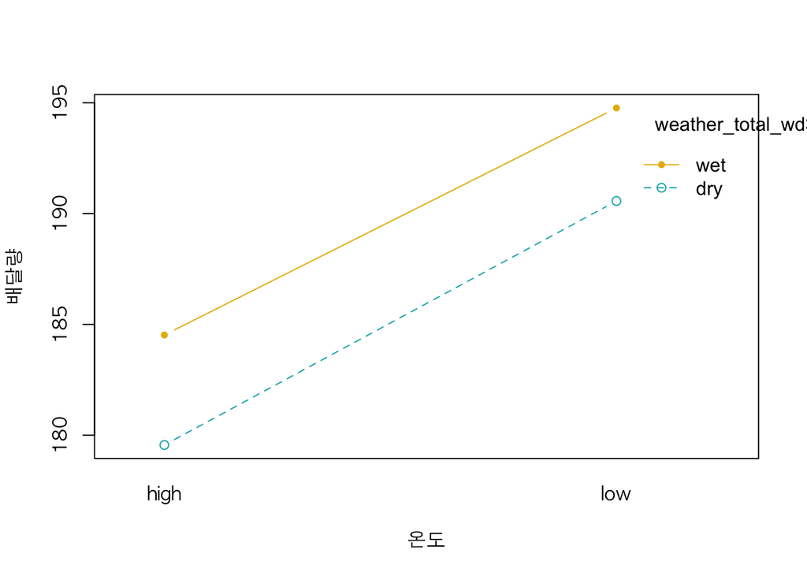

```r
interaction.plot(x.factor = weather_total_wd$avg_temp,
                 trace.factor = weather_total_wd$precipitation,
                 response = weather_total_wd$`Daily delivery`,
                 fun = mean,
                 type = "b",
                 legend = TRUE,
                 xlab = "온도",
                 ylab = "배달량",
                 pch=c(1,20),
                 col = c("#00AFBB", "#E7B800"),
                 family = "AppleGothic")
```

### 3-3. 워드클라우드를 이용한 날씨에 따른 배달 인기 메뉴 분석

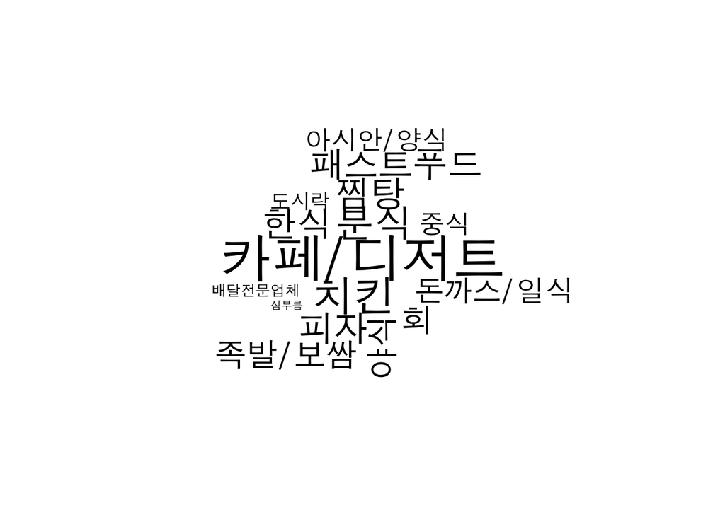

```r
#install.packages("worldcloud")
#install.packages("RcolorBrewer)
library(RColorBrewer)
library(wordcloud)
# 날씨에 따른 배달 인기 메뉴 분석의 워드클라우드
weather_menu <- full_join(Sudo_delivery, delivery_weather)
weather_menu_hot <- weather_menu %>% filter(weather_menu$type == 'hot')

weather_menu_cold <- weather_menu %>% filter(weather_menu$type == 'cold')

weather_menu_cool <- weather_menu %>% filter(weather_menu$type == 'cool')

weather_menu_warm <- weather_menu %>% filter(weather_menu$type == 'warm')

weather_menu_rain <- weather_menu %>% filter(weather_menu$type == 'rain')

weather_menu_snow <- weather_menu %>% filter(weather_menu$type == 'snow')

weather_menu_snow_num <- weather_menu_snow %>%
  group_by(menu) %>%
  summarise(
    "일일 배달량" = n()
  )

weather_menu_cold_num <- weather_menu_cold %>%
  group_by(menu) %>%
  summarise(
    "일일 배달량" = n()
  )

weather_menu_cool_num <- weather_menu_cool %>%
  group_by(menu) %>%
  summarise(
    "일일 배달량" = n()
  )

weather_menu_warm_num <- weather_menu_warm %>%
  group_by(menu) %>%
  summarise(
    "일일 배달량" = n()
  )

weather_menu_rain_num <- weather_menu_rain %>%
  group_by(menu) %>%
  summarise(
    "일일 배달량" = n()
  )

weather_menu_hot_num <- weather_menu_hot %>%
  group_by(menu) %>%
  summarise(
    "일일 배달량" = n()
  )

snow_menu <- wordcloud(words = weather_menu_snow_num$menu, #단어,
          freq = weather_menu_snow_num$`일일 배달량`, #메뉴 배달량
          min.freq = 2,
          max.words = 200,
          random.order = F,
          rot.per = .1,
          scale = c(3, 0.4),
         family = "AppleGothic") ; snow_menu
```

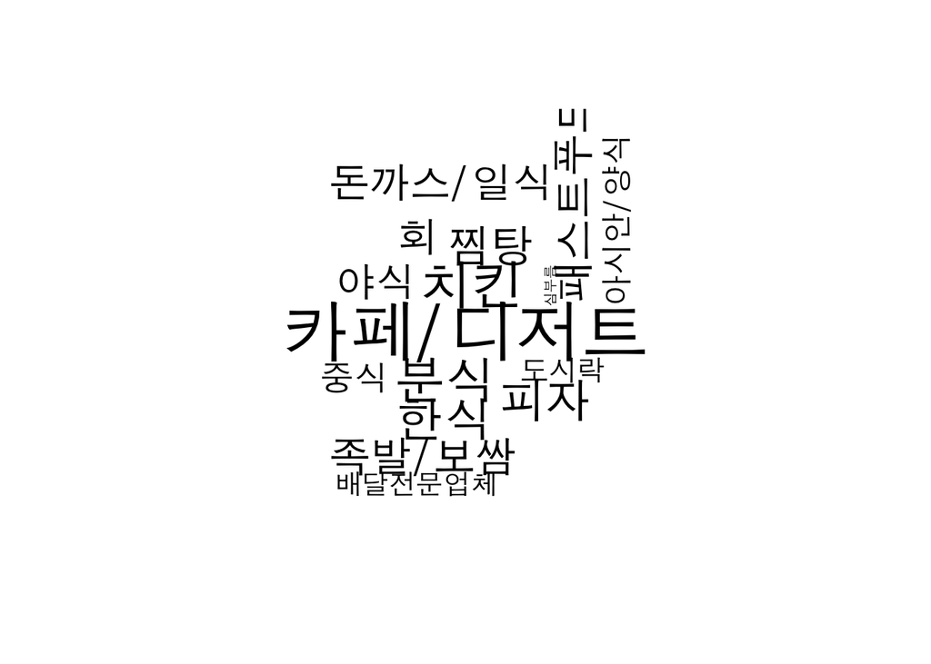

```r
hot_menu <- wordcloud(words = weather_menu_hot_num$menu, #단어,
          freq = weather_menu_hot_num$`일일 배달량`, #메뉴 배달량
          min.freq = 2,
          max.words = 200,
          random.order = F,
          rot.per = .1,
          scale = c(3, 0.4),
         family = "AppleGothic") ; hot_menu
```

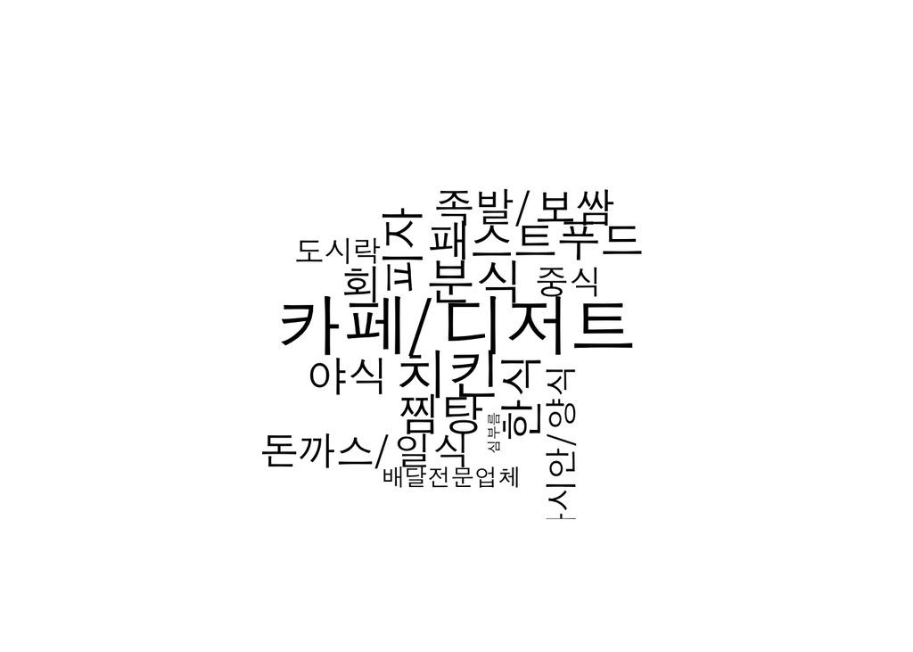

```r
cool_menu <- wordcloud(words = weather_menu_cool_num$menu, #단어,
          freq = weather_menu_cool_num$`일일 배달량`, #메뉴 배달량
          min.freq = 2,
          max.words = 200,
          random.order = F,
          rot.per = .1,
          scale = c(3, 0.4),
         family = "AppleGothic") ; cool_menu
```

```r
sunny_menu <- wordcloud(words = weather_menu_sunny_num$menu, #단어,
          freq = weather_menu_sunny_num$`일일 배달량`, #메뉴 배달량
          min.freq = 2,
          max.words = 200,
          random.order = F,
          rot.per = .1,
          scale = c(3, 0.4),
         family = "AppleGothic") ; sunny_menu
```

```
## Error in wordcloud(words = weather_menu_sunny_num$menu, freq = weather_menu_sunny_num$`일일 배달량`, : object 'weather_menu_sunny_num' not found
```

```
## Error in eval(expr, envir, enclos): object 'sunny_menu' not found
```

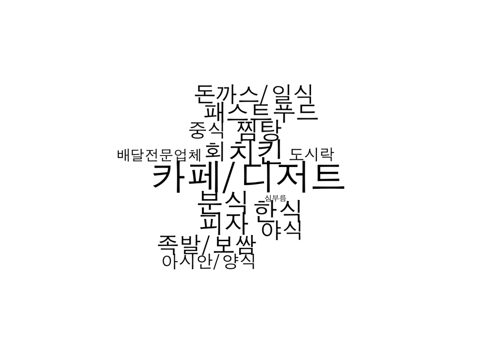

```r
rain_menu <- wordcloud(words = weather_menu_rain_num$menu, #단어,
          freq = weather_menu_rain_num$`일일 배달량`, #메뉴 배달량
          min.freq = 2,
          max.words = 200,
          random.order = F,
          rot.per = .1,
          scale = c(3, 0.4),
         family = "AppleGothic") ; rain_menu
```

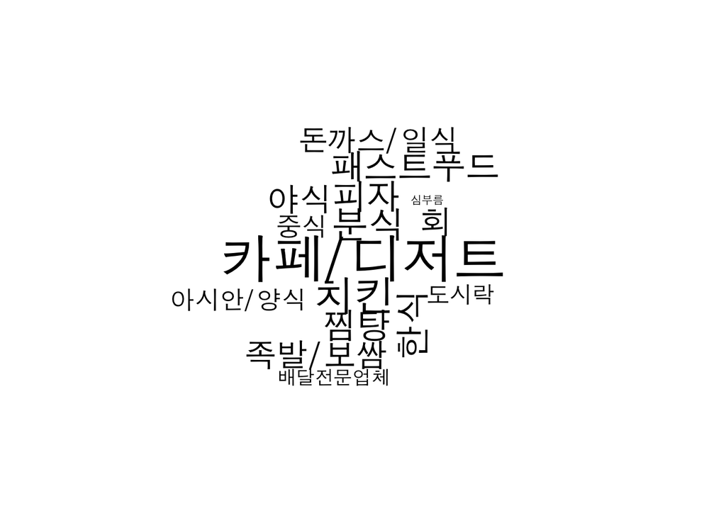

```r
cold_menu <- wordcloud(words = weather_menu_cold_num$menu, #단어,
          freq = weather_menu_cold_num$`일일 배달량`, #메뉴 배달량
          min.freq = 2,
          max.words = 200,
          random.order = F,
          rot.per = .1,
          scale = c(3, 0.4),
         family = "AppleGothic") ; cold_menu
```

## 4. 결론

- 주제 구체화 과정과 가설 설정 가정에서 날씨가 배달량에 큰 영향을 미칠 것이라 생각했다. 때문에 온도와 강수량을 기준으로 하여 다양한 추론 통계 분석을 진행하였다. 그 결과 강수량 기준으로 통계 분석을 진행했을 때 날씨가 배달량에 유의미한 영향을 미치지 않았다. 반면에 온도를 기준으로 통계 분석을 진행했을 때 날씨가 배달량에 유의미한 영향을 미치는 점을 알 수 있었다. 또한 기술통계 페이지에서는 psych 라는 패키지를 통해 기술 통계 분석을 유용하게 할 수 있었고, pie3d 패키지를 비롯해 barplot, pie chart 등 도식화 하는 과정까지 진행했다. 추론통계 페이지에서는 카이스퀘어, t-test, ANOVA 등의 기법을 활용해 분석했으며, plotmeans를 통해 도식화도 진행했다. 추가적으로 날씨에 따른 인기 배달 음식을 지표화하여 워드클라우드로 나타내보았다.